# Maps, Coordinate Reference Systems and Visualising Geographic Data with mapmisc

Mollweide

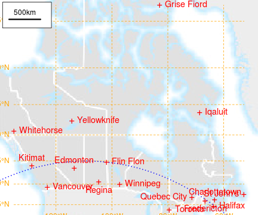

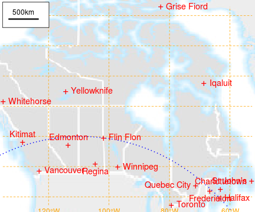

5. Spherical Merc
6. Long-Lat

```r
crsList <- list("Oblique Merc" = cproj, "Lambert" = CRS("+init=epsg:3347"),
    "2pt Equidist" = tpeqd(cities[cities$name %in% c("Edmonton", "Toronto"), ]),
    "Mollweide" = moll(flinflon, angle = 0), "Spherical Merc" = mapmisc::crsMerc,
    "Long-Lat" = mapmisc::crsLL)
```

The cities and Great Circle are transformed to each of the projections with `mapply`.

```r
citiesT <- mapply(spTransform, CRSobj = crsList, MoreArgs = list(x = cities))
```

Code for retrieving background maps and for producing Figure 7 appears in the Appendix.

Table 2: Mean and standard deviation of the percentage by which Euclidean distance overestimates Great Circle distance for various map projections. The bottom two rows involve distances involving at least one of Grise Fiord, Iqaluit, Whitehorse and Yellowknife, with the top two rows including only distances not involving any of these four northern locations.

|  | Oblique Merc | Lambert | 2pt Equidist | Mollweide | Spherical Merc |
| --- | --- | --- | --- | --- | --- |
| **south** |  |  |  |  |  |
| mean | $-0.05$ | $-0.23$ | $-0.13$ | $-6.68$ | $54.19$ |
| sd | $0.13$ | $1.03$ | $0.34$ | $5.22$ | $8.01$ |
| **north** |  |  |  |  |  |
| mean | $1.74$ | $-2.54$ | $0.54$ | $-1.10$ | $131.43$ |
| sd | $1.65$ | $0.32$ | $0.81$ | $6.58$ | $43.82$ |

Table 2 compares Euclidean distance to true (or Great Circle) distance for each of the map projections, with the percentage by which the former overestimates the latter for each pair of cities summarised. The first two rows give the mean and standard deviation for the percentage of overestimation of distances between the southern locations (which exclude Grise Fiord, Iqaluit, Whitehorse, and Yellowknife). The Oblique Mercator’s underestimation by 0.05% betters the other projections, and the Mollweide’s 6.7% underestimation is excusable given the projection’s aim of preserving areas rather than distances. The Lambert’s 0.23% underestimation appears respectable though the comparatively large standard deviation of 1.03% indicates several city pairs with Euclidean distances deviating several percent from their true separations. Distances involving at least one of the four northern locations are less accurate for all projections (the Mollweide notwithstanding), and the Oblique Mercator’s 1.7% overestimation betrays the fact that these northern points were not part of `omerc`’s optimisation criteria. The Two-Point Equidistant projection is notable in its consistency and accuracy, and the Lambert projection does not appear to be a CRS which statisticians should consider using for points in Canada when accuracy of Euclidean distances is the primary concern.

## 3 Maps with colour scales

A separate set of facilities in *mapmisc*, complementing but disjoint from the tools related to map projections, assists with the use of colour scales and legends for maps in R. The *RColorBrewer* package gives R users access to the popular ColorBrewer collection of palettes, all of which are displayed in Table 4 in the Appendix. These colours can be used with the functions in the *classInt* package to create colour scales, and the venerable `legend` function is extremely versatile in its ability to create map legends. The steps involved in defining and using colour scales have been streamlined and consolidated into the `colourScale`, `legendBreaks` and `legendTable` functions in *mapmisc*. The process of creating suitable bins, assigning colours to data points based on these bins, specifying transparency when overlaying colours on background maps, and displaying the intervals and colours in a legend has been simplified as much as possible in *mapmisc*, although at least five separate lines of R code are required to produce a single map.

### 3.1 Colours with polygon data

Consider, as a motivating example, the task of visualising the spatial variation in fertility rates in Europe using data available from the statistical office of the European Union (EUROSTAT). EUROSTAT divides the territory of the European Union and several adjoining nations into statistical units organised in a hierarchical system named “nomenclature des unités territoriales statistiques” and given the memorable acronym of NUTS.Social and demographic data on the statistical units are available at http://ec.europa.eu/eurostat/data/database, and their boundaries can be obtained from http://ec.europa.eu/eurostat/web/gisco/geodata/reference-data/administrative-units-statistical-units. Figure 8 shows the fertility rate in 2010 for 456 units of level 2 in NUTS.

```r
euroF
```

```r
## class       : SpatialPolygonsDataFrame
## features    : 456
## extent      : -24.5, 44.8, 34.6, 71.2  (xmin, xmax, ymin, ymax)
## coord. ref. : +proj=longlat +ellps=GRS80 +no_defs
## variables   : 29
## names       : NUTS_ID, STAT_LEVL_, SHAPE_Leng, SHAPE_Area, age.geo.time, X2013, ...
## min values  :      AT,          0,      0.134,   1.00e+00,     TOTAL,AT, 0.96 , ...
## max values  :    UKN0,          2,      9.946,   9.96e-01,   TOTAL,UKN0, 3.75 , ...
```

The polygons are transformed to the European Terrestrial Reference System (EPSG code 3034) below.

```r
euroF <- spTransform(euroF, CRS("+init=epsg:3034"))
```

Colours in Figure 8 relate to the `X2010` variable in `euroF` (fertility in 2010), with the colours themselves taken from the “Spectral” palette of *RColorBrewer*. Below the `colourScale` function creates eight bins (`breaks = 8`) for values of `euroF$X2010`, reversing the colours so that blues correspond to low values and reds are large values (`rev = TRUE`).

```r
ecol <- colourScale(euroF$X2010, col = "Spectral", breaks = 8, rev = TRUE,
    style = "jenks", dec = 1, opacity = 0.5)
```

The `style` argument controls how the breaks are computed, and the `"jenks"` option corresponds to the “natural breaks” algorithm from (Jenks and Caspall 1971) (see also Pebesma and Bivand 2005 3.5.2) implemented in the `classIntervals` function of the *classInt* package. A number of clustering algorithms for defining break points are provided by `classIntervals`, and the options for the `style =` argument described in the help files for `classIntervals` are all available using the identically named argument in `colourScale`. The break points are rounded to one decimal place as a consequence of the `dec = 1` argument, and the `opacity = 0.5` option gives the plotted colours 50% transparency.

The result of a call to `colourScale` is a list containing the break points for bins (`breaks`), colours associated with the bins (`col`), and a vector of length 456 (`plot`) with one colour per region.

```r
names(ecol)
```

```r
## [1] "col"        "breaks"     "colOpacity" "plot"
```

```r
ecol$breaks
```

```r
## [1] 1.0 1.3 1.4 1.6 1.8 2.0 2.4 2.9 3.8
```

```r
ecol$col
```

```r
## [1] "#3288BD" "#66C2A5" "#ABDDA4" "#E6F598" "#FEE08B" "#FDAE61" "#F46D43"
## [8] "#D53E4F"
```

```r
length(ecol$plot)
```

```r
## [1] 456
```

The `breaks` and `col` elements are used for displaying a legend, whereas the `plot` element can be passed as a `col =` argument when running `plot` on a “SpatialPoints” or “SpatialPolygons” object. Following the retrieval of the background map with

```r
euroMap <- openmap(euroF, path = "osm-no-labels")
```

Figure 8, minus the country names, can be produced as follows.

```r
map.new(euroF)
plot(euroMap, add = TRUE)
plot(euroF, col = ecol$plot, add = TRUE, border = "lightgrey")
legendBreaks("topright", ecol, title = "fertility", bg = "white")
scaleBar(euroF, "bottom", bty = "n")
```

Notice the `col = ecol$plot` argument specifying the colours with which each region is filled, and that the borders of each region were given by `border = "lightgrey"`. The legend on the right is added with `legendBreaks`, which passes most of its arguments to the standard `legend` function from the *graphics* package. The role of `legendBreaks` is to ensure the 9 numeric break points are printed near the boundaries between the coloured squares (as opposed to aligned with their centres).

The country names in Figure 8 are taken from the `wrld_simpl` object used earlier, although all countries smaller than Albania have been removed in order to keep the map from becoming too crowded. Below a portion of the globe in the northern hemisphere is cropped from `wrld_simpl` and subsequently re-projected to the European CRS.

```r
data("wrld_simpl", package = "maptools")
worldCrop <- raster::crop(wrld_simpl, extent(-20, 100, 0, 90))
worldE <- spTransform(worldCrop, projection(euroF))
```

The areas of the countries are computed from the map `worldMoll` in the Mollweide projection, merged into the `worldE` object, and all countries at least as large as Albania are retained.

```r
worldE$area <- rgeos::gArea(worldMoll, byid = TRUE)[as.character(worldE$ISO3)]
worldE <- worldE[worldE$area >= worldE@data[worldE$NAME == "Albania", "area"], ]
```

The names are added to the plot with the `text` function.

```r
text(worldE, labels = worldE$NAME, cex = 0.8)
```

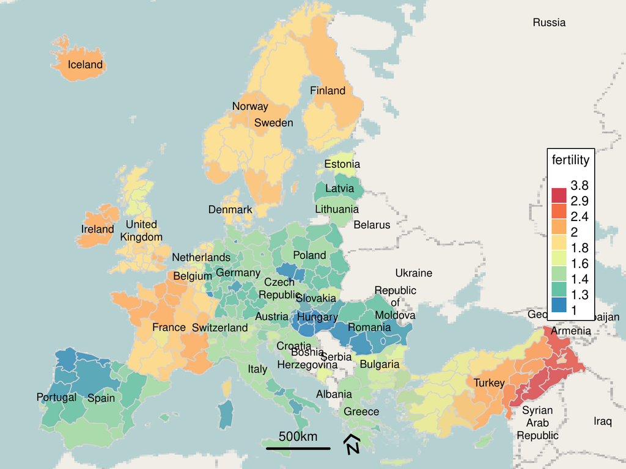

Figure 8: Fertility in Europe by NUTS. Background © [OpenStreetMap](http://openstreetmap.org/copyright), © EuroGeographics for the administrative boundaries.

Using the `style = "jenks"` argument for `colourScale` triggers a clustering algorithm in function `classIntervals` which can be time consuming for large datasets. The `"quantile"` and `"equal"` options for the `style` argument use quantiles and equally spaced break points respectively, with the latter able to have breaks equally spaced on a transformed scale (i.e. log or square root). Some examples appear below.

```r
colourScale(euroF$X2010, breaks = 8, style = "quantile", dec = 1)$breaks
```

```r
## [1] 1.0 1.4 1.5 1.7 1.9 2.0 3.8
```

```r
colourScale(euroF$X2010, breaks = 8, style = "equal")$breaks
```

```r
## [1] 1.04 1.43 1.82 2.21 2.60 2.99 3.38 3.77
```

```r
colourScale(euroF$X2010, breaks = 8, style = "equal", transform = "log")$breaks
```

```r
## [1] 1.04 1.25 1.50 1.81 2.17 2.61 3.14 3.77
```

```r
colourScale(euroF$X2010, breaks = 8, style = "equal", dec = 0)$breaks
```

```r
## [1] 1 2 3 4
```

The final set of break points has a `dec = 0` argument, and although 8 breaks have been requested only 4 unique breaks remain after rounding to the nearest integer.

### 3.2 Rasters and colour scales

Figure 9 shows two elevation maps of New Zealand produced with the assistance of the `colourScale` and `legendBreaks` functions. The *raster* package provides versions of the `plot` function for use with rasters, and using `colourScale` with rasters is slightly different from its use in the previous section.

The elevation data is obtained using the *raster* package’s `getData` function.

```r
nzAltFull <- raster::getData("alt", country = "NZL", keepzip = TRUE)
```

The `nzAlt` object is a list of two elements, with elevation in two disjoint areas which comprise New Zealand. The first element includes the main island, its CRS is incomplete (at the time of writing) and should be re-specified.

```r
nzAlt <- nzAltFull[[1]]
projection(nzAlt) <- CRS("+init=epsg:4326")
```

This raster includes a number of outlying islands, and its size becomes more manageable after the main island is extracted using the previously computed `nzClip` object.

```r
dim(nzAlt)
```

```r
## [1] 2244 1572    1
```

```r
nzAlt <- raster::crop(nzAlt, extent(nzClip))
dim(nzAlt)
```

```r
## [1] 1544 1458    1
```

This smaller raster is now re-projected to the rotated Oblique Mercator projection used earlier, with the `filename =` argument allowing for the resulting data to be stored as a file in R’s working directory rather than in memory.

```r
nzAltRot <- projectRaster(nzAlt, crs = projection(nzRot), filename = "nzAltRot.grd")
dim(nzAltRot)
```

```r
## [1] 2424 3069    1
```

Re-projecting the raster has made it larger, as the rectangular bounding box of `nzAlt` becomes a diamond when rotated and `nzAltRot` has a bounding box large enough to contain this diamond. The `crop` function is used to pare this raster down to the same extent as the `nzRot` object.

```r
(nzAltCrop <- raster::crop(nzAltRot, extent(nzRot)))
```

```r
## class       : RasterLayer
## dimensions  : 1895, 1369, 2594255  (nrow, ncol, ncell)
## resolution  : 554, 727  (x, y)
## extent      : -624719, 133707, -291892, 1085773  (xmin, xmax, ymin, ymax)
## coord. ref. : +proj=omerc +lat_0=-45 +lonc=170 +alpha=40 +k=1 +x_0=0 +y_0=0 +gam...
## data source : in memory
## names       : NZL1_msk_alt
## values      : -11.1, 2960  (min, max)
```

Raster images are typically large, with `nzAltCrop` having over 2 million cells, and computing break points using all of the data points would be time consuming. The *raster* package provide easy access to the maximum and minimum values ($-11$ and 2960 above), which makes equally spaced break points (`style = "equal"` below) quick to compute. All other styles of breaks are computed using a sample of 20,000 cells taken using *raster*’s `sampleRegular` function.

```r
nzAltCol <- colourScale(nzAltCrop, breaks = 7, col = terrain.colors, style = "equal",
    dec = -2)
```

Here the `col =` argument was given the `terrain.colors` function, and any function accepting a single integer argument and returning a vector with the specified number of colours would suffice. Below a second colour scale is computed using the `"OrRd"` colour palette and a supplied vector of breaks.

```r
nzAltTrans <- colourScale(nzAltCrop, breaks = c(-20, 100, 500, 1200, 2000, 3100),
    col = "OrRd", style = "fixed", opacity = c(0.2, 1))
```

Here the `opacity` argument has been given a vector of length 2, giving the opacity of the first colour and last colour respectively with intervening colours having opacities which are linear interpolations of these values.

Figure 9a is produced with code below.

```r
par(bg = "lightblue1")
map.new(nzRot)
par(bg = "white")
plot(nzAltCrop, col = nzAltCol$col, breaks = nzAltCol$breaks, legend = FALSE,
    add = TRUE)
plot(nzRot, add = TRUE, border = col2html("red", 0.4))
legendBreaks("bottomleft", nzAltCol, title = "metres", bg = "white")
scaleBar(nzRot, "left")
```

The code for Figure 9b is below.

```r
map.new(nzRot)
plotRGB(nzBg, add = TRUE)
plot(nzAltCrop, col = nzAltTrans$colOpacity, breaks = nzAltTrans$breaks,
    legend = FALSE, add = TRUE)
legendBreaks("bottomleft", nzAltTrans, title = "metres")
scaleBar(nzRot, "left")
```

Here the `colOpacity` element of the colour scale, which has 2-digit opacity levels appended to each specified colour, is passed as `col =` argument to allow the satellite photo beneath to be viewed.

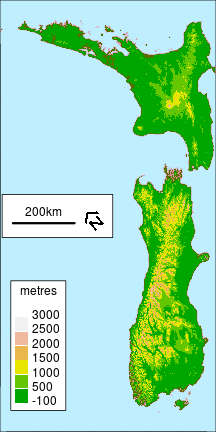

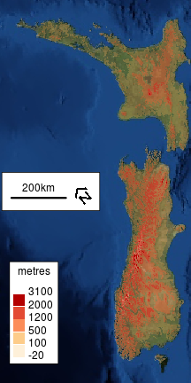

1. `terrain.colors()`
2. `“OrRd”` colours with opacity. Tiles courtesy of [MapQuest](http://www.mapquest.com).

Figure 9: Elevation maps of New Zealand using colours from `terrain.colors` and the `“OrRd”` colours from *RColorBrewer*.